# Relationship between IPI and duration of C1/C2

# 1 Data preprocessing

## 1.1 Load required packages

```r
library("tidyr")
library("dplyr")
library("stringr")
library("car")
```

```r
library("ggplot2")
library("mgcv")
library("itsadug")
```

## 1.2 Read data

```r
df <- readRDS("C:/Users/Jidde/Desktop/analysis/data/modelling_data_CC.rds")
df <- rename(df, IPI = time.lag.norm)
```

## 1.3 Clean data

Remove all the rows that have NA in the dependent variable and drop ‘empty’ levels, convert variables to factors and create trimmed dataset.

```r
df$subj <- as.factor(df$subj)

df <- df[complete.cases(df$IPI),]
df <- droplevels(df)

# Sort data
df <- df[order(df$subj, df$recording.no),]

# convert to factors/numeric
df$prompt <- as.factor(df$prompt)
df$condition <- as.factor(df$condition)


# remove all the recordings without a speech rate measure:
# df <- df %>% drop_na(duration.tt)

# remove participants with only a few datapoints
#remove <- c("PD19", "CTRL19")
#df.trim <- df[! df$subj %in% remove, ]
#df.trim <- droplevels(df.trim)


# create df without sx
#df.trim <- df.trim[! df.trim$cluster == "sx", ]
#df.trim <- droplevels(df.trim)
#levels(df.trim$cluster)

# create df without spr
df.nospr <- df[! df$cluster == "spr", ]
df.nospr <- droplevels(df.nospr)
levels(df.nospr$cluster)
```

```
## [1] "sm" "sp" "sx"
```

```r
df.nospr$cluster <- relevel(df.nospr$cluster, ref = "sm")



# merge /sm/ and /sp/
df.nospr$c2type <- ifelse(df.nospr$cluster == "sx","lingual C2","labial C2")
df.nospr$c2type <- as.factor(df.nospr$c2type)
table(df.nospr$c2type, df.nospr$cluster)
```

```
##
##               sm  sp  sx
##   labial C2  406 432   0
##   lingual C2   0   0 300
```

```r
df.nospr$condition <- recode_factor(df.nospr$condition, C = "singleton",
                                CC = "cluster")

df.nospr$group <- recode_factor(df.nospr$group, CTRL = "typical")
df.nospr$group<- relevel(df.nospr$group, ref = "PD")


rm(df)
```

Create one var for duration of C1/C2

```r
df.nospr <- df.nospr %>%
  gather(whichC, durationC, dur.C1.norm, dur.C2.norm) %>%
  arrange(subj, group, recording.no)

df.nospr$whichC <- as.factor(df.nospr$whichC)

#df.nospr$durationC <- df.nospr$durationC - mean(df.nospr$durationC) # center continues variable
df.nospr$cluster <- relevel(df.nospr$cluster, ref = "sx")
df.nospr$whichC <- relevel(df.nospr$whichC, ref = "dur.C1.norm")
df.nospr$whichC <- recode_factor(df.nospr$whichC, dur.C1.norm = "initial",
                                dur.C2.norm = "prevocalic")
```

Create binary dummy variables:

```r
df.nospr$IsC2 <- (df.nospr$whichC == "prevocalic")*1
df.nospr$IsTP <- (df.nospr$group == "typical")*1
df.nospr$IsSm = (df.nospr$cluster == "sm")*1
df.nospr$IsSx = (df.nospr$cluster == "sx")*1
df.nospr$IsC2lin = (df.nospr$cluster == "sx")*1

df.nospr$IsTP_C2 = (df.nospr$whichC == "prevocalic" & df.nospr$group == "typical")*1
df.nospr$IsPD_C2 = (df.nospr$whichC == "prevocalic" & df.nospr$group == "PD")*1

df.nospr$IsTP_C2lin = (df.nospr$cluster == "sx" & df.nospr$group == "typical")*1
```

Create ordered factor:

```r
df.nospr$group.ord <- as.ordered(df.nospr$group)
contrasts(df.nospr$group.ord) <- "contr.treatment"

df.nospr$whichC.ord <- as.ordered(df.nospr$whichC)
contrasts(df.nospr$whichC.ord) <- "contr.treatment"

df.nospr$cluster.ord <- as.ordered(df.nospr$cluster)
contrasts(df.nospr$cluster.ord) <- "contr.treatment"

df.nospr$gender.ord <- as.ordered(df.nospr$gender)
contrasts(df.nospr$gender.ord) <- "contr.treatment"

df.nospr$c2type.ord <- as.ordered(df.nospr$c2type)
contrasts(df.nospr$c2type.ord) <- "contr.treatment"

df.nospr$TPlingual.ord <- as.ordered(df.nospr$group =="typical" & df.nospr$c2type == "lingual C2")
contrasts(df.nospr$TPlingual.ord) <- "contr.treatment"

df.nospr$PDlingual.ord <- as.ordered(df.nospr$group =="PD" & df.nospr$c2type == "lingual C2")
contrasts(df.nospr$TPlingual.ord) <- "contr.treatment"

df.nospr$c2type_group <- interaction(df.nospr$c2type, df.nospr$group)
df.nospr$c2type_group.ord <- as.ordered(df.nospr$c2type_group)
contrasts(df.nospr$c2type_group.ord) <- "contr.treatment"
```

## 1.4 Hypothesis testing

Base model:

```r
summary(mBase <- bam(durationC ~ s(subj, bs = "re"), data = df.nospr, method = "ML"))
```

```
##
## Family: gaussian
## Link function: identity
##
## Formula:
## durationC ~ s(subj, bs = "re")
##
## Parametric coefficients:
##             Estimate Std. Error t value Pr(>|t|)
## (Intercept) 0.057536   0.001841   31.25   <2e-16 ***
## ---
## Signif. codes:  0 '***' 0.001 '**' 0.01 '*' 0.05 '.' 0.1 ' ' 1
##
## Approximate significance of smooth terms:
##           edf Ref.df     F p-value
## s(subj) 35.29     46 3.452  <2e-16 ***
## ---
## Signif. codes:  0 '***' 0.001 '**' 0.01 '*' 0.05 '.' 0.1 ' ' 1
##
## R-sq.(adj) =  0.0655   Deviance explained =    8%
## -ML = -4023.6  Scale est. = 0.0016543  n = 2276
```

OK.

Add smooth over IPI

```r
summary(m1 <- bam(durationC ~ s(IPI) + s(subj, bs = "re"), data = df.nospr, method = "ML"))
```

```
##
## Family: gaussian
## Link function: identity
##
## Formula:
## durationC ~ s(IPI) + s(subj, bs = "re")
##
## Parametric coefficients:
##             Estimate Std. Error t value Pr(>|t|)
## (Intercept)  0.05748    0.00191   30.09   <2e-16 ***
## ---
## Signif. codes:  0 '***' 0.001 '**' 0.01 '*' 0.05 '.' 0.1 ' ' 1
##
## Approximate significance of smooth terms:
##           edf Ref.df      F p-value
## s(IPI)   1.00  1.001 45.546  <2e-16 ***
## s(subj) 36.17 46.000  3.857  <2e-16 ***
## ---
## Signif. codes:  0 '***' 0.001 '**' 0.01 '*' 0.05 '.' 0.1 ' ' 1
##
## R-sq.(adj) =  0.0852   Deviance explained =   10%
## -ML = -4046.1  Scale est. = 0.0016195  n = 2276
```

```r
compareML(mBase, m1)
```

```
## mBase: durationC ~ s(subj, bs = "re")
##
## m1: durationC ~ s(IPI) + s(subj, bs = "re")
```

```
##
## Chi-square test of ML scores
## -----
##   Model    Score Edf Difference    Df   p.value Sig.
## 1 mBase -4023.63   2
## 2    m1 -4046.11   4     22.481 2.000 1.725e-10  ***
##
## AIC difference: 46.59, model m1 has lower AIC.
```

Yes.

Add random smooth?

```r
summary(m2 <- bam(durationC ~ s(IPI) + s(IPI, subj, bs = "fs", m =1), data = df.nospr, discrete = T, nthreads = 2))
```

```
##
## Family: gaussian
## Link function: identity
##
## Formula:
## durationC ~ s(IPI) + s(IPI, subj, bs = "fs", m = 1)
##
## Parametric coefficients:
##             Estimate Std. Error t value Pr(>|t|)
## (Intercept) 0.057535   0.001954   29.45   <2e-16 ***
## ---
## Signif. codes:  0 '***' 0.001 '**' 0.01 '*' 0.05 '.' 0.1 ' ' 1
##
## Approximate significance of smooth terms:
##                edf  Ref.df      F p-value
## s(IPI)       3.871   4.877 11.037  <2e-16 ***
## s(IPI,subj) 36.567 403.000  0.453  <2e-16 ***
## ---
## Signif. codes:  0 '***' 0.001 '**' 0.01 '*' 0.05 '.' 0.1 ' ' 1
##
## R-sq.(adj) =  0.0888   Deviance explained = 10.5%
## fREML = -4035.8  Scale est. = 0.0016131  n = 2276
```

Yes.

Plot

```
## Summary:
##  * IPI : numeric predictor; with 30 values ranging from -0.117647 to 0.336918.
##  * subj : factor; set to the value(s): CTRL21. (Might be canceled as random effect, check below.)
##  * NOTE : The following random effects columns are canceled: s(IPI,subj)
##
```

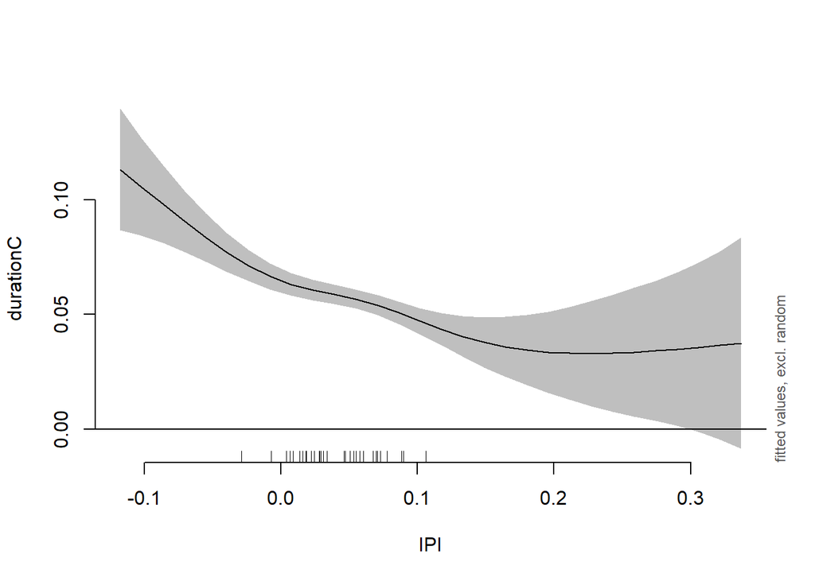

```r
plot_smooth(m2, view = "IPI")
```

Check:

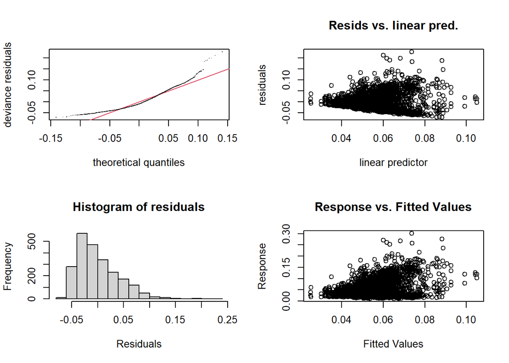

```
##
## Method: fREML   Optimizer: perf chol
## $grad
## [1] -1.150825e-06 -1.493454e-05 -9.375076e-07  2.617735e-05
##
## $hess
##            [,1]          [,2]          [,3]          [,4]
##    6.444220e-01  1.150845e-06 -1.592916e-01 -1.435366e+00
##    1.150845e-06  1.493455e-05  9.375128e-07 -2.617765e-05
##   -1.592916e-01  9.375128e-07  1.426410e+01 -1.828339e+01
## d -1.435366e+00 -2.617765e-05 -1.828339e+01  1.137000e+03
##
## Model rank =  433 / 433
##
## Basis dimension (k) checking results. Low p-value (k-index<1) may
## indicate that k is too low, especially if edf is close to k'.
##
##                 k'    edf k-index p-value
## s(IPI)        9.00   3.87    1.61       1
## s(IPI,subj) 423.00  36.57    1.61       1
```

```r
gam.check(m2)
```

Looks heavily right skewed.

Fit with log:

```r
summary(m2_log <- bam(durationC ~ s(IPI) + s(IPI, subj, bs = "fs", m =1), data = df.nospr, family =Gamma(link=log), discrete = T, nthreads = 2))
```

```
##
## Family: Gamma
## Link function: log
##
## Formula:
## durationC ~ s(IPI) + s(IPI, subj, bs = "fs", m = 1)
##
## Parametric coefficients:
##             Estimate Std. Error t value Pr(>|t|)
## (Intercept) -2.88540    0.03457  -83.47   <2e-16 ***
## ---
## Signif. codes:  0 '***' 0.001 '**' 0.01 '*' 0.05 '.' 0.1 ' ' 1
##
## Approximate significance of smooth terms:
##                edf  Ref.df      F p-value
## s(IPI)       2.752   3.568 13.913  <2e-16 ***
## s(IPI,subj) 37.941 403.000  0.555  <2e-16 ***
## ---
## Signif. codes:  0 '***' 0.001 '**' 0.01 '*' 0.05 '.' 0.1 ' ' 1
##
## R-sq.(adj) =  0.0893   Deviance explained = 11.6%
## fREML =   2328  Scale est. = 0.42787   n = 2276
```

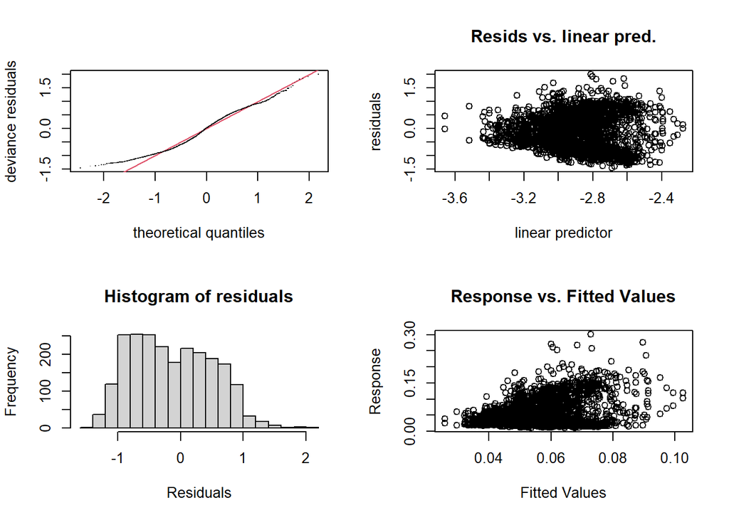

```
##
## Method: fREML   Optimizer: perf chol
## $grad
## [1] -9.819531e-05 -8.038964e-06 -8.477601e-06  2.629213e-03
##
## $hess
##            [,1]          [,2]          [,3]          [,4]
##    5.692075e-02  6.409808e-07 -1.205107e-01 -8.760853e-01
##    6.409808e-07  8.038971e-06  3.310116e-07 -1.776080e-05
##   -1.205107e-01  3.310116e-07  1.541423e+01 -1.897026e+01
## d -8.760853e-01 -1.776080e-05 -1.897026e+01  1.136997e+03
##
## Model rank =  433 / 433
##
## Basis dimension (k) checking results. Low p-value (k-index<1) may
## indicate that k is too low, especially if edf is close to k'.
##
##                 k'    edf k-index p-value
## s(IPI)        9.00   2.75    1.63       1
## s(IPI,subj) 423.00  37.94    1.63       1
```

```r
gam.check(m2_log)
```

Looks a bit better.

Compare model with and without IPI using the right (log) distribution:

```r
summary(mBaseLog <- bam(durationC ~ s(subj, bs = "re"), data = df.nospr, family =Gamma(link=log), method = "ML"))
```

```
##
## Family: Gamma
## Link function: log
##
## Formula:
## durationC ~ s(subj, bs = "re")
##
## Parametric coefficients:
##             Estimate Std. Error t value Pr(>|t|)
## (Intercept) -2.87946    0.03307  -87.08   <2e-16 ***
## ---
## Signif. codes:  0 '***' 0.001 '**' 0.01 '*' 0.05 '.' 0.1 ' ' 1
##
## Approximate significance of smooth terms:
##           edf Ref.df     F p-value
## s(subj) 37.04     46 4.356  <2e-16 ***
## ---
## Signif. codes:  0 '***' 0.001 '**' 0.01 '*' 0.05 '.' 0.1 ' ' 1
##
## R-sq.(adj) =  0.0661   Deviance explained = 9.34%
## -ML = 2337.9  Scale est. = 0.44123   n = 2276
```

```r
summary(mHypolog <- bam(durationC ~ s(IPI) + s(subj, bs = "re"), data = df.nospr, family =Gamma(link=log), method = "ML"))
```

```
##
## Family: Gamma
## Link function: log
##
## Formula:
## durationC ~ s(IPI) + s(subj, bs = "re")
##
## Parametric coefficients:
##             Estimate Std. Error t value Pr(>|t|)
## (Intercept) -2.88577    0.03395  -85.01   <2e-16 ***
## ---
## Signif. codes:  0 '***' 0.001 '**' 0.01 '*' 0.05 '.' 0.1 ' ' 1
##
## Approximate significance of smooth terms:
##           edf Ref.df      F p-value
## s(IPI)   1.00  1.001 46.499  <2e-16 ***
## s(subj) 37.68 46.000  4.769  <2e-16 ***
## ---
## Signif. codes:  0 '***' 0.001 '**' 0.01 '*' 0.05 '.' 0.1 ' ' 1
##
## R-sq.(adj) =  0.0878   Deviance explained = 11.4%
## -ML = 2306.3  Scale est. = 0.4286    n = 2276
```

```r
compareML(mBaseLog, mHypolog)
```

```
## mBaseLog: durationC ~ s(subj, bs = "re")
##
## mHypolog: durationC ~ s(IPI) + s(subj, bs = "re")
```

```
##
## Chi-square test of ML scores
## -----
##      Model    Score Edf Difference    Df   p.value Sig.
## 1 mBaseLog 2337.895   2
## 2 mHypolog 2306.275   4     31.619 2.000 1.853e-14  ***
##
## AIC difference: 53.28, model mHypolog has lower AIC.
```

Model criticism, trimming:

```r
df.nospr2 <- df.nospr[abs(scale(resid(m2_log))) < 2.5, ] # trim model
(1 - (nrow(df.nospr2))/nrow(df.nospr)) * 100
```

```
## [1] 0.483304
```

0.5% removed.

Refit:

```r
summary(hypo_log_trim <- bam(durationC ~ s(IPI) + s(IPI, subj, bs = "fs", m =1), data = df.nospr2, family =Gamma(link=log), discrete = T, nthreads = 2))
```

```
##
## Family: Gamma
## Link function: log
##
## Formula:
## durationC ~ s(IPI) + s(IPI, subj, bs = "fs", m = 1)
##
## Parametric coefficients:
##             Estimate Std. Error t value Pr(>|t|)
## (Intercept) -2.90319    0.03423  -84.82   <2e-16 ***
## ---
## Signif. codes:  0 '***' 0.001 '**' 0.01 '*' 0.05 '.' 0.1 ' ' 1
##
## Approximate significance of smooth terms:
##                edf  Ref.df      F p-value
## s(IPI)       2.801   3.627 14.040  <2e-16 ***
## s(IPI,subj) 38.194 405.000  0.578  <2e-16 ***
## ---
## Signif. codes:  0 '***' 0.001 '**' 0.01 '*' 0.05 '.' 0.1 ' ' 1
##
## R-sq.(adj) =  0.0958   Deviance explained = 11.8%
## fREML = 2282.5  Scale est. = 0.40234   n = 2265
```

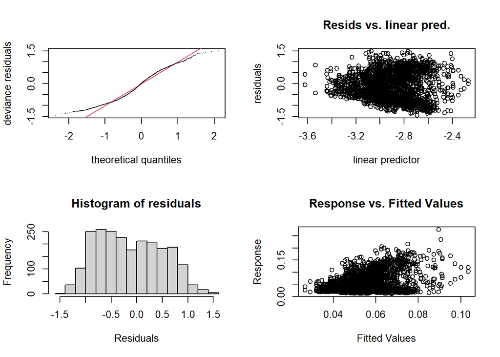

```
##
## Method: fREML   Optimizer: perf chol
## $grad
## [1] -3.417061e-03 -2.550074e-05  7.724538e-05  2.724097e-02
##
## $hess
##            [,1]          [,2]          [,3]          [,4]
##    1.120614e-01  1.693374e-06 -1.134343e-01 -8.972157e-01
##    1.693374e-06  2.550080e-05  1.276325e-06 -5.753582e-05
##   -1.134343e-01  1.276325e-06  1.567518e+01 -1.909700e+01
## d -8.972157e-01 -5.753582e-05 -1.909700e+01  1.131473e+03
##
## Model rank =  433 / 433
##
## Basis dimension (k) checking results. Low p-value (k-index<1) may
## indicate that k is too low, especially if edf is close to k'.
##
##                k'   edf k-index p-value
## s(IPI)        9.0   2.8    1.64       1
## s(IPI,subj) 423.0  38.2    1.64       1
```

```r
gam.check(hypo_log_trim)
```

OK.

Visualize:

```r
#Plot using ordered factor:
summary(mplot <- bam(durationC ~ group.ord + s(IPI) + s(IPI, subj, bs = "fs", m =1), data = df.nospr2, family =Gamma(link=log), discrete = T, nthreads = 2))
```

```
##
## Family: Gamma
## Link function: log
##
## Formula:
## durationC ~ group.ord + s(IPI) + s(IPI, subj, bs = "fs", m = 1)
##
## Parametric coefficients:
##                  Estimate Std. Error t value Pr(>|t|)
## (Intercept)      -2.89040    0.04972  -58.14   <2e-16 ***
## group.ordtypical -0.02490    0.06919   -0.36    0.719
## ---
## Signif. codes:  0 '***' 0.001 '**' 0.01 '*' 0.05 '.' 0.1 ' ' 1
##
## Approximate significance of smooth terms:
##                edf  Ref.df      F p-value
## s(IPI)       2.807   3.634 14.049  <2e-16 ***
## s(IPI,subj) 37.497 402.000  0.584  <2e-16 ***
## ---
## Signif. codes:  0 '***' 0.001 '**' 0.01 '*' 0.05 '.' 0.1 ' ' 1
##
## R-sq.(adj) =  0.0959   Deviance explained = 11.8%
## fREML = 2284.2  Scale est. = 0.40227   n = 2265
```

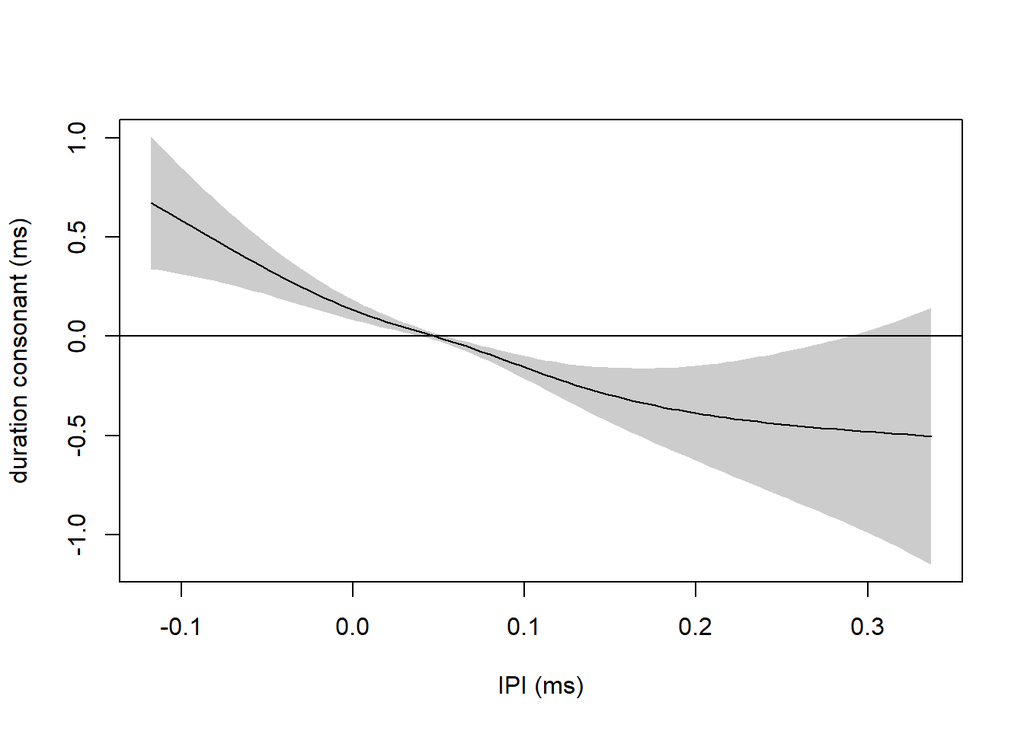

```r
plot(mplot, select = 1, shade = T, rug = F, ylab = "duration consonant (ms)", xlab = "IPI (ms)")
abline(h=0)
```

# GAM models

## 1.5 Exploraratory testing

Add group:

```r
summary(m2_log.alt <- bam(durationC ~ s(IPI) + s(IPI, subj, bs = "fs", m =1), data = df.nospr, family =Gamma(link=log), select = T, discrete = T, nthreads = 2))
```

```
##
## Family: Gamma
## Link function: log
##
## Formula:
## durationC ~ s(IPI) + s(IPI, subj, bs = "fs", m = 1)
##
## Parametric coefficients:
##             Estimate Std. Error t value Pr(>|t|)
## (Intercept) -2.88535    0.03456  -83.49   <2e-16 ***
## ---
## Signif. codes:  0 '***' 0.001 '**' 0.01 '*' 0.05 '.' 0.1 ' ' 1
##
## Approximate significance of smooth terms:
##                edf Ref.df     F p-value
## s(IPI)       2.547      9 5.477  <2e-16 ***
## s(IPI,subj) 37.942    403 0.555  <2e-16 ***
## ---
## Signif. codes:  0 '***' 0.001 '**' 0.01 '*' 0.05 '.' 0.1 ' ' 1
##
## R-sq.(adj) =  0.089   Deviance explained = 11.6%
## fREML = 2327.1  Scale est. = 0.42779   n = 2276
```

```r
summary(ex0.alt <- bam(durationC ~ group + s(IPI) + s(IPI, subj, bs = "fs", m =1), data = df.nospr, family =Gamma(link=log), select = T, discrete = T, nthreads = 2))
```

```
##
## Family: Gamma
## Link function: log
##
## Formula:
## durationC ~ group + s(IPI) + s(IPI, subj, bs = "fs", m = 1)
##
## Parametric coefficients:
##              Estimate Std. Error t value Pr(>|t|)
## (Intercept)  -2.87700    0.05026 -57.239   <2e-16 ***
## grouptypical -0.01629    0.06993  -0.233    0.816
## ---
## Signif. codes:  0 '***' 0.001 '**' 0.01 '*' 0.05 '.' 0.1 ' ' 1
##
## Approximate significance of smooth terms:
##                edf Ref.df     F p-value
## s(IPI)       2.577      9 5.498  <2e-16 ***
## s(IPI,subj) 37.269    402 0.558  <2e-16 ***
## ---
## Signif. codes:  0 '***' 0.001 '**' 0.01 '*' 0.05 '.' 0.1 ' ' 1
##
## R-sq.(adj) =  0.089   Deviance explained = 11.6%
## fREML = 2328.9  Scale est. = 0.42763   n = 2276
```

```r
compareML(m2_log.alt, ex0.alt)
```

```
## m2_log.alt: durationC ~ s(IPI) + s(IPI, subj, bs = "fs", m = 1)
##
## ex0.alt: durationC ~ group + s(IPI) + s(IPI, subj, bs = "fs", m = 1)
##
## Model m2_log.alt preferred: lower fREML score (1.726), and lower df (1.000).
## -----
##        Model    Score Edf Difference     Df
## 1    ex0.alt 2328.855   6
## 2 m2_log.alt 2327.129   5      1.726 -1.000
##
## AIC difference: 0.26, model ex0.alt has lower AIC.
```

Binary smooth for each group over IPI?

```r
summary(mGroupBin<- bam(durationC ~ s(IPI) + s(IPI, by = IsTP) + s(IPI, subj, bs = "fs", m =1), data = df.nospr, family =Gamma(link=log), discrete = T, nthreads = 2))
```

```
##
## Family: Gamma
## Link function: log
##
## Formula:
## durationC ~ s(IPI) + s(IPI, by = IsTP) + s(IPI, subj, bs = "fs",
##     m = 1)
##
## Parametric coefficients:
##             Estimate Std. Error t value Pr(>|t|)
## (Intercept) -2.87590    0.04995  -57.57   <2e-16 ***
## ---
## Signif. codes:  0 '***' 0.001 '**' 0.01 '*' 0.05 '.' 0.1 ' ' 1
##
## Approximate significance of smooth terms:
##                edf  Ref.df      F  p-value
## s(IPI)       2.076   2.644 10.649 5.47e-06 ***
## s(IPI):IsTP  3.988   4.760  1.099    0.333
## s(IPI,subj) 37.156 402.000  0.544  < 2e-16 ***
## ---
## Signif. codes:  0 '***' 0.001 '**' 0.01 '*' 0.05 '.' 0.1 ' ' 1
##
## R-sq.(adj) =  0.0912   Deviance explained = 11.8%
## fREML = 2331.3  Scale est. = 0.42598   n = 2276
```

Add whichC (compare using select = T)

```r
summary(ex1.alt <- bam(durationC ~ s(IPI) + whichC + s(IPI, subj, bs = "fs", m =1), data = df.nospr, family =Gamma(link=log), select = T, discrete = T, nthreads = 2))
```

```
##
## Family: Gamma
## Link function: log
##
## Formula:
## durationC ~ s(IPI) + whichC + s(IPI, subj, bs = "fs", m = 1)
##
## Parametric coefficients:
##                  Estimate Std. Error t value Pr(>|t|)
## (Intercept)      -2.47398    0.02676  -92.43   <2e-16 ***
## whichCprevocalic -1.07782    0.01750  -61.60   <2e-16 ***
## ---
## Signif. codes:  0 '***' 0.001 '**' 0.01 '*' 0.05 '.' 0.1 ' ' 1
##
## Approximate significance of smooth terms:
##                edf Ref.df      F p-value
## s(IPI)       5.044      9 21.998  <2e-16 ***
## s(IPI,subj) 56.372    415  0.785  <2e-16 ***
## ---
## Signif. codes:  0 '***' 0.001 '**' 0.01 '*' 0.05 '.' 0.1 ' ' 1
##
## R-sq.(adj) =  0.481   Deviance explained = 66.7%
## fREML = 1252.9  Scale est. = 0.17419   n = 2276
```

```r
compareML(m2_log.alt, ex1.alt)
```

```
## m2_log.alt: durationC ~ s(IPI) + s(IPI, subj, bs = "fs", m = 1)
##
## ex1.alt: durationC ~ s(IPI) + whichC + s(IPI, subj, bs = "fs", m = 1)
```

```
##
## Chi-square test of fREML scores
## -----
##        Model    Score Edf Difference    Df  p.value Sig.
## 1 m2_log.alt 2327.129   5
## 2    ex1.alt 1252.900   6   1074.229 1.000  < 2e-16  ***
##
## AIC difference: 2273.90, model ex1.alt has lower AIC.
```

Yes.

Add slopes

```r
summary(ex2 <- bam(durationC ~ s(IPI) + whichC + s(subj, whichC, bs="re") + s(IPI, subj, bs = "fs", m =1), data = df.nospr, family =Gamma(link=log), discrete = T, nthreads = 2))
```

```
##
## Family: Gamma
## Link function: log
##
## Formula:
## durationC ~ s(IPI) + whichC + s(subj, whichC, bs = "re") + s(IPI,
##     subj, bs = "fs", m = 1)
##
## Parametric coefficients:
##                  Estimate Std. Error t value Pr(>|t|)
## (Intercept)      -2.50964    0.04197  -59.80   <2e-16 ***
## whichCprevocalic -1.05527    0.05917  -17.84   <2e-16 ***
## ---
## Signif. codes:  0 '***' 0.001 '**' 0.01 '*' 0.05 '.' 0.1 ' ' 1
##
## Approximate significance of smooth terms:
##                   edf Ref.df      F p-value
## s(IPI)          5.037   5.97 26.876  <2e-16 ***
## s(whichC,subj) 84.643  92.00 13.034  <2e-16 ***
## s(IPI,subj)    38.744 411.00  0.212  0.0294 *
## ---
## Signif. codes:  0 '***' 0.001 '**' 0.01 '*' 0.05 '.' 0.1 ' ' 1
##
## R-sq.(adj) =  0.613   Deviance explained =   77%
## fREML = 964.36  Scale est. = 0.12745   n = 2276
```

Required.

Add cluster:

```r
summary(ex2.alt <- bam(durationC ~ s(IPI) + whichC + s(subj, whichC, bs="re") + s(IPI, subj, bs = "fs", m =1), data = df.nospr, family =Gamma(link=log), select = T, discrete = T, nthreads = 2))
```

```
##
## Family: Gamma
## Link function: log
##
## Formula:
## durationC ~ s(IPI) + whichC + s(subj, whichC, bs = "re") + s(IPI,
##     subj, bs = "fs", m = 1)
##
## Parametric coefficients:
##                  Estimate Std. Error t value Pr(>|t|)
## (Intercept)      -2.50968    0.04198  -59.78   <2e-16 ***
## whichCprevocalic -1.05526    0.05918  -17.83   <2e-16 ***
## ---
## Signif. codes:  0 '***' 0.001 '**' 0.01 '*' 0.05 '.' 0.1 ' ' 1
##
## Approximate significance of smooth terms:
##                   edf Ref.df      F p-value
## s(IPI)          4.967      9 26.360  <2e-16 ***
## s(whichC,subj) 84.652     92 13.046  <2e-16 ***
## s(IPI,subj)    38.469    411  0.209  0.0304 *
## ---
## Signif. codes:  0 '***' 0.001 '**' 0.01 '*' 0.05 '.' 0.1 ' ' 1
##
## R-sq.(adj) =  0.614   Deviance explained =   77%
## fREML = 963.73  Scale est. = 0.12743   n = 2276
```

```r
summary(ex3.alt <- bam(durationC ~ s(IPI) + whichC + cluster + s(subj, whichC, bs="re") + s(IPI, subj, bs = "fs", m =1), data = df.nospr, family =Gamma(link=log), select = T, discrete = T, nthreads = 2))
```

```
##
## Family: Gamma
## Link function: log
##
## Formula:
## durationC ~ s(IPI) + whichC + cluster + s(subj, whichC, bs = "re") +
##     s(IPI, subj, bs = "fs", m = 1)
##
## Parametric coefficients:
##                  Estimate Std. Error t value Pr(>|t|)
## (Intercept)      -2.52580    0.04477 -56.416   <2e-16 ***
## whichCprevocalic -1.05442    0.05924 -17.798   <2e-16 ***
## clustersm         0.02369    0.02344   1.011    0.312
## clustersp         0.01873    0.02215   0.846    0.398
## ---
## Signif. codes:  0 '***' 0.001 '**' 0.01 '*' 0.05 '.' 0.1 ' ' 1
##
## Approximate significance of smooth terms:
##                   edf Ref.df      F p-value
## s(IPI)          4.966      9 27.929  <2e-16 ***
## s(whichC,subj) 84.649     92 13.035  <2e-16 ***
## s(IPI,subj)    37.624    411  0.202  0.0321 *
## ---
## Signif. codes:  0 '***' 0.001 '**' 0.01 '*' 0.05 '.' 0.1 ' ' 1
##
## R-sq.(adj) =  0.616   Deviance explained =   77%
## fREML =  969.4  Scale est. = 0.12771   n = 2276
```

```r
compareML(ex2.alt, ex3.alt)
```

```
## ex2.alt: durationC ~ s(IPI) + whichC + s(subj, whichC, bs = "re") + s(IPI,
##     subj, bs = "fs", m = 1)
##
## ex3.alt: durationC ~ s(IPI) + whichC + cluster + s(subj, whichC, bs = "re") +
##     s(IPI, subj, bs = "fs", m = 1)
##
## Model ex2.alt preferred: lower fREML score (5.673), and lower df (2.000).
## -----
##     Model    Score Edf Difference     Df
## 1 ex3.alt 969.4040   9
## 2 ex2.alt 963.7314   7      5.673 -2.000
##
## AIC difference: -3.68, model ex2.alt has lower AIC.
```

No.

In interaction with group?

```r
summary(ex4.alt <- bam(durationC ~ s(IPI) + whichC + group*cluster + s(subj, whichC, bs="re") + s(IPI, subj, bs = "fs", m =1), data = df.nospr, family =Gamma(link=log), select = T, discrete = T, nthreads = 2))
```

```
##
## Family: Gamma
## Link function: log
##
## Formula:
## durationC ~ s(IPI) + whichC + group * cluster + s(subj, whichC,
##     bs = "re") + s(IPI, subj, bs = "fs", m = 1)
##
## Parametric coefficients:
##                        Estimate Std. Error t value Pr(>|t|)
## (Intercept)            -2.43902    0.05563 -43.841  < 2e-16 ***
## whichCprevocalic       -1.05403    0.05915 -17.820  < 2e-16 ***
## grouptypical           -0.18512    0.06629  -2.792  0.00528 **
## clustersm              -0.03619    0.03070  -1.179  0.23863
## clustersp              -0.06510    0.02978  -2.186  0.02894 *
## grouptypical:clustersm  0.13897    0.04341   3.201  0.00139 **
## grouptypical:clustersp  0.17878    0.04184   4.273 2.01e-05 ***
## ---
## Signif. codes:  0 '***' 0.001 '**' 0.01 '*' 0.05 '.' 0.1 ' ' 1
##
## Approximate significance of smooth terms:
##                   edf Ref.df      F p-value
## s(IPI)          5.017      9 32.962  <2e-16 ***
## s(whichC,subj) 83.796     91 13.140  <2e-16 ***
## s(IPI,subj)    33.534    410  0.166  0.0507 .
## ---
## Signif. codes:  0 '***' 0.001 '**' 0.01 '*' 0.05 '.' 0.1 ' ' 1
##
## R-sq.(adj) =  0.618   Deviance explained = 77.1%
## fREML = 965.79  Scale est. = 0.12689   n = 2276
```

```r
compareML(ex2.alt, ex4.alt)
```

```
## ex2.alt: durationC ~ s(IPI) + whichC + s(subj, whichC, bs = "re") + s(IPI,
##     subj, bs = "fs", m = 1)
##
## ex4.alt: durationC ~ s(IPI) + whichC + group * cluster + s(subj, whichC,
##     bs = "re") + s(IPI, subj, bs = "fs", m = 1)
##
## Model ex2.alt preferred: lower fREML score (2.055), and lower df (5.000).
## -----
##     Model    Score Edf Difference     Df
## 1 ex4.alt 965.7866  12
## 2 ex2.alt 963.7314   7      2.055 -5.000
##
## AIC difference: 10.81, model ex4.alt has lower AIC.
```

No.

Add c2type?

```r
summary(ex5.alt <- bam(durationC ~ s(IPI) + whichC + c2type + s(subj, whichC, bs="re") + s(IPI, subj, bs = "fs", m =1), data = df.nospr, family =Gamma(link=log), select = T, discrete = T, nthreads = 2))
```

```
##
## Family: Gamma
## Link function: log
##
## Formula:
## durationC ~ s(IPI) + whichC + c2type + s(subj, whichC, bs = "re") +
##     s(IPI, subj, bs = "fs", m = 1)
##
## Parametric coefficients:
##                  Estimate Std. Error t value Pr(>|t|)
## (Intercept)      -2.50467    0.04234 -59.149   <2e-16 ***
## whichCprevocalic -1.05461    0.05923 -17.804   <2e-16 ***
## c2typelingual C2 -0.02081    0.02074  -1.003    0.316
## ---
## Signif. codes:  0 '***' 0.001 '**' 0.01 '*' 0.05 '.' 0.1 ' ' 1
##
## Approximate significance of smooth terms:
##                   edf Ref.df      F p-value
## s(IPI)          4.985      9 27.933  <2e-16 ***
## s(whichC,subj) 84.649     92 13.038  <2e-16 ***
## s(IPI,subj)    37.595    411  0.201  0.0327 *
## ---
## Signif. codes:  0 '***' 0.001 '**' 0.01 '*' 0.05 '.' 0.1 ' ' 1
##
## R-sq.(adj) =  0.615   Deviance explained =   77%
## fREML = 966.38  Scale est. = 0.12772   n = 2276
```

```r
compareML(ex2.alt, ex5.alt)
```

```
## ex2.alt: durationC ~ s(IPI) + whichC + s(subj, whichC, bs = "re") + s(IPI,
##     subj, bs = "fs", m = 1)
##
## ex5.alt: durationC ~ s(IPI) + whichC + c2type + s(subj, whichC, bs = "re") +
##     s(IPI, subj, bs = "fs", m = 1)
##
## Model ex2.alt preferred: lower fREML score (2.651), and lower df (1.000).
## -----
##     Model    Score Edf Difference     Df
## 1 ex5.alt 966.3819   8
## 2 ex2.alt 963.7314   7      2.651 -1.000
##
## AIC difference: -1.83, model ex2.alt has lower AIC.
```

No.

In interaction with group?

```r
summary(ex6.alt <- bam(durationC ~ s(IPI) + whichC + group*c2type + s(subj, whichC, bs="re") + s(IPI, subj, bs = "fs", m =1), data = df.nospr, family =Gamma(link=log), select = T, discrete = T, nthreads = 2))
```

```
##
## Family: Gamma
## Link function: log
##
## Formula:
## durationC ~ s(IPI) + whichC + group * c2type + s(subj, whichC,
##     bs = "re") + s(IPI, subj, bs = "fs", m = 1)
##
## Parametric coefficients:
##                               Estimate Std. Error t value Pr(>|t|)
## (Intercept)                   -2.49058    0.05239 -47.535  < 2e-16 ***
## whichCprevocalic              -1.05429    0.05915 -17.823  < 2e-16 ***
## grouptypical                  -0.02495    0.06016  -0.415   0.6784
## c2typelingual C2               0.05167    0.02712   1.905   0.0569 .
## grouptypical:c2typelingual C2 -0.16048    0.03840  -4.179 3.05e-05 ***
## ---
## Signif. codes:  0 '***' 0.001 '**' 0.01 '*' 0.05 '.' 0.1 ' ' 1
##
## Approximate significance of smooth terms:
##                   edf Ref.df      F p-value
## s(IPI)          5.048      9 33.728  <2e-16 ***
## s(whichC,subj) 83.809     91 13.154  <2e-16 ***
## s(IPI,subj)    32.661    410  0.156  0.0645 .
## ---
## Signif. codes:  0 '***' 0.001 '**' 0.01 '*' 0.05 '.' 0.1 ' ' 1
##
## R-sq.(adj) =  0.618   Deviance explained = 77.1%
## fREML = 961.06  Scale est. = 0.12696   n = 2276
```

```r
compareML(ex2.alt, ex6.alt)
```

```
## ex2.alt: durationC ~ s(IPI) + whichC + s(subj, whichC, bs = "re") + s(IPI,
##     subj, bs = "fs", m = 1)
##
## ex6.alt: durationC ~ s(IPI) + whichC + group * c2type + s(subj, whichC,
##     bs = "re") + s(IPI, subj, bs = "fs", m = 1)
```

```
##
## Chi-square test of fREML scores
## -----
##     Model    Score Edf Difference    Df p.value Sig.
## 1 ex2.alt 963.7314   7
## 2 ex6.alt 961.0589  10      2.672 3.000   0.148
##
## AIC difference: 12.84, model ex6.alt has lower AIC.
```

No.

Add recording.no:

```r
summary(ex5.alt <- bam(durationC ~ s(IPI) + whichC + s(subj, whichC, bs="re") + s(IPI, subj, bs = "fs", m =1), data = df.nospr, family =Gamma(link=log), select = T, discrete = T, nthreads = 2))
```

```
##
## Family: Gamma
## Link function: log
##
## Formula:
## durationC ~ s(IPI) + whichC + s(subj, whichC, bs = "re") + s(IPI,
##     subj, bs = "fs", m = 1)
##
## Parametric coefficients:
##                  Estimate Std. Error t value Pr(>|t|)
## (Intercept)      -2.50968    0.04198  -59.78   <2e-16 ***
## whichCprevocalic -1.05526    0.05918  -17.83   <2e-16 ***
## ---
## Signif. codes:  0 '***' 0.001 '**' 0.01 '*' 0.05 '.' 0.1 ' ' 1
##
## Approximate significance of smooth terms:
##                   edf Ref.df      F p-value
## s(IPI)          4.967      9 26.360  <2e-16 ***
## s(whichC,subj) 84.652     92 13.046  <2e-16 ***
## s(IPI,subj)    38.469    411  0.209  0.0304 *
## ---
## Signif. codes:  0 '***' 0.001 '**' 0.01 '*' 0.05 '.' 0.1 ' ' 1
##
## R-sq.(adj) =  0.614   Deviance explained =   77%
## fREML = 963.73  Scale est. = 0.12743   n = 2276
```

```r
summary(ex6.alt <- bam(durationC ~ s(IPI) + whichC + s(recording.no) + s(subj, whichC, bs="re") + s(IPI, subj, bs = "fs", m =1), data = df.nospr, family =Gamma(link=log), select = T, discrete = T, nthreads = 2))
```

```
##
## Family: Gamma
## Link function: log
##
## Formula:
## durationC ~ s(IPI) + whichC + s(recording.no) + s(subj, whichC,
##     bs = "re") + s(IPI, subj, bs = "fs", m = 1)
##
## Parametric coefficients:
##                  Estimate Std. Error t value Pr(>|t|)
## (Intercept)      -2.51100    0.04203  -59.74   <2e-16 ***
## whichCprevocalic -1.05442    0.05925  -17.80   <2e-16 ***
## ---
## Signif. codes:  0 '***' 0.001 '**' 0.01 '*' 0.05 '.' 0.1 ' ' 1
##
## Approximate significance of smooth terms:
##                     edf Ref.df      F p-value
## s(IPI)           5.0167      9 26.444  <2e-16 ***
## s(recording.no)  0.6619      9  0.241  0.0809 .
## s(whichC,subj)  84.6810     92 13.105  <2e-16 ***
## s(IPI,subj)     38.4153    411  0.209  0.0307 *
## ---
## Signif. codes:  0 '***' 0.001 '**' 0.01 '*' 0.05 '.' 0.1 ' ' 1
##
## R-sq.(adj) =  0.615   Deviance explained =   77%
## fREML = 963.12  Scale est. = 0.12715   n = 2276
```

```r
compareML(ex5.alt, ex6.alt)
```

```
## ex5.alt: durationC ~ s(IPI) + whichC + s(subj, whichC, bs = "re") + s(IPI,
##     subj, bs = "fs", m = 1)
##
## ex6.alt: durationC ~ s(IPI) + whichC + s(recording.no) + s(subj, whichC,
##     bs = "re") + s(IPI, subj, bs = "fs", m = 1)
```

```
##
## Chi-square test of fREML scores
## -----
##     Model    Score Edf Difference    Df p.value Sig.
## 1 ex5.alt 963.7314   7
## 2 ex6.alt 963.1236   9      0.608 2.000   0.545
##
## AIC difference: 0.93, model ex6.alt has lower AIC.
```

No.

Separate for group?

```r
summary(ex7 <- bam(durationC ~ s(IPI) + whichC + s(recording.no) + s(recording.no, by = IsTP) + s(subj, whichC, bs="re") + s(IPI, subj, bs = "fs", m =1), data = df.nospr, family =Gamma(link=log), discrete = T, nthreads = 2))
```

```
##
## Family: Gamma
## Link function: log
##
## Formula:
## durationC ~ s(IPI) + whichC + s(recording.no) + s(recording.no,
##     by = IsTP) + s(subj, whichC, bs = "re") + s(IPI, subj, bs = "fs",
##     m = 1)
##
## Parametric coefficients:
##                  Estimate Std. Error t value Pr(>|t|)
## (Intercept)      -2.47852    0.05203  -47.63   <2e-16 ***
## whichCprevocalic -1.05410    0.05924  -17.79   <2e-16 ***
## ---
## Signif. codes:  0 '***' 0.001 '**' 0.01 '*' 0.05 '.' 0.1 ' ' 1
##
## Approximate significance of smooth terms:
##                        edf  Ref.df      F p-value
## s(IPI)                5.12   6.056 26.144  <2e-16 ***
## s(recording.no)       1.00   1.000  0.277   0.599
## s(recording.no):IsTP  2.00   2.000  0.988   0.372
## s(whichC,subj)       83.74  91.000 13.081  <2e-16 ***
## s(IPI,subj)          39.57 410.000  0.219   0.024 *
## ---
## Signif. codes:  0 '***' 0.001 '**' 0.01 '*' 0.05 '.' 0.1 ' ' 1
##
## R-sq.(adj) =  0.616   Deviance explained = 77.1%
## fREML = 970.69  Scale est. = 0.127     n = 2276
```

No.

Add gender:

```r
summary(ex8.alt <- bam(durationC ~ s(IPI) + whichC + gender + s(subj, whichC, bs="re") +  s(IPI, subj, bs = "fs", m =1), data = df.nospr, family =Gamma(link=log), select = T, discrete = T, nthreads = 2))
```

```
##
## Family: Gamma
## Link function: log
##
## Formula:
## durationC ~ s(IPI) + whichC + gender + s(subj, whichC, bs = "re") +
##     s(IPI, subj, bs = "fs", m = 1)
##
## Parametric coefficients:
##                  Estimate Std. Error t value Pr(>|t|)
## (Intercept)      -2.53587    0.04521 -56.092   <2e-16 ***
## whichCprevocalic -1.05526    0.05880 -17.946   <2e-16 ***
## genderF           0.10147    0.06757   1.502    0.133
## ---
## Signif. codes:  0 '***' 0.001 '**' 0.01 '*' 0.05 '.' 0.1 ' ' 1
##
## Approximate significance of smooth terms:
##                   edf Ref.df      F p-value
## s(IPI)          4.966      9 26.401  <2e-16 ***
## s(whichC,subj) 83.641     91 12.970  <2e-16 ***
## s(IPI,subj)    38.519    410  0.209  0.0268 *
## ---
## Signif. codes:  0 '***' 0.001 '**' 0.01 '*' 0.05 '.' 0.1 ' ' 1
##
## R-sq.(adj) =  0.614   Deviance explained =   77%
## fREML = 964.35  Scale est. = 0.12738   n = 2276
```

```r
compareML(ex5.alt, ex8.alt)
```

```
## ex5.alt: durationC ~ s(IPI) + whichC + s(subj, whichC, bs = "re") + s(IPI,
##     subj, bs = "fs", m = 1)
##
## ex8.alt: durationC ~ s(IPI) + whichC + gender + s(subj, whichC, bs = "re") +
##     s(IPI, subj, bs = "fs", m = 1)
##
## Model ex5.alt preferred: lower fREML score (0.616), and lower df (1.000).
## -----
##     Model    Score Edf Difference     Df
## 1 ex8.alt 964.3477   8
## 2 ex5.alt 963.7314   7      0.616 -1.000
##
## AIC difference: 0.24, model ex8.alt has lower AIC.
```

No.

Add gender in interaction with group?

```r
summary(ex9.alt <- bam(durationC ~ s(IPI) + whichC + group*gender + s(subj, whichC, bs="re") + s(IPI, subj, bs = "fs", m =1), data = df.nospr, family =Gamma(link=log), select = T, discrete = T, nthreads = 2))
```

```
##
## Family: Gamma
## Link function: log
##
## Formula:
## durationC ~ s(IPI) + whichC + group * gender + s(subj, whichC,
##     bs = "re") + s(IPI, subj, bs = "fs", m = 1)
##
## Parametric coefficients:
##                      Estimate Std. Error t value Pr(>|t|)
## (Intercept)          -2.50670    0.05648 -44.381   <2e-16 ***
## whichCprevocalic     -1.05533    0.05895 -17.902   <2e-16 ***
## grouptypical         -0.05952    0.06885  -0.865    0.387
## genderF               0.13301    0.10267   1.295    0.195
## grouptypical:genderF -0.04399    0.13700  -0.321    0.748
## ---
## Signif. codes:  0 '***' 0.001 '**' 0.01 '*' 0.05 '.' 0.1 ' ' 1
##
## Approximate significance of smooth terms:
##                   edf Ref.df      F p-value
## s(IPI)          4.963      9 26.139  <2e-16 ***
## s(whichC,subj) 81.835     89 13.022  <2e-16 ***
## s(IPI,subj)    38.429    408  0.208  0.0199 *
## ---
## Signif. codes:  0 '***' 0.001 '**' 0.01 '*' 0.05 '.' 0.1 ' ' 1
##
## R-sq.(adj) =  0.613   Deviance explained =   77%
## fREML = 966.58  Scale est. = 0.1274    n = 2276
```

```r
compareML(ex5.alt, ex9.alt)
```

```
## ex5.alt: durationC ~ s(IPI) + whichC + s(subj, whichC, bs = "re") + s(IPI,
##     subj, bs = "fs", m = 1)
##
## ex9.alt: durationC ~ s(IPI) + whichC + group * gender + s(subj, whichC,
##     bs = "re") + s(IPI, subj, bs = "fs", m = 1)
##
## Model ex5.alt preferred: lower fREML score (2.848), and lower df (3.000).
## -----
##     Model    Score Edf Difference     Df
## 1 ex9.alt 966.5790  10
## 2 ex5.alt 963.7314   7      2.848 -3.000
##
## AIC difference: -0.06, model ex5.alt has lower AIC.
```

No.

Add age:

```r
summary(ex10.alt <- bam(durationC ~ s(IPI) + whichC  + s(age) + s(subj, whichC, bs="re") + s(IPI, subj, bs = "fs", m =1), data = df.nospr, family =Gamma(link=log), select = T, discrete = T, nthreads = 2))
```

```
##
## Family: Gamma
## Link function: log
##
## Formula:
## durationC ~ s(IPI) + whichC + s(age) + s(subj, whichC, bs = "re") +
##     s(IPI, subj, bs = "fs", m = 1)
##
## Parametric coefficients:
##                  Estimate Std. Error t value Pr(>|t|)
## (Intercept)      -2.51197    0.04210  -59.67   <2e-16 ***
## whichCprevocalic -1.05531    0.05885  -17.93   <2e-16 ***
## ---
## Signif. codes:  0 '***' 0.001 '**' 0.01 '*' 0.05 '.' 0.1 ' ' 1
##
## Approximate significance of smooth terms:
##                    edf Ref.df      F p-value
## s(IPI)          4.9646      9 25.650  <2e-16 ***
## s(age)          0.6441      9  3.637  0.2132
## s(whichC,subj) 83.9772     92 12.754  <2e-16 ***
## s(IPI,subj)    38.5444    411  0.203  0.0212 *
## ---
## Signif. codes:  0 '***' 0.001 '**' 0.01 '*' 0.05 '.' 0.1 ' ' 1
##
## R-sq.(adj) =  0.614   Deviance explained =   77%
## fREML = 963.59  Scale est. = 0.1274    n = 2276
```

```r
compareML(ex5.alt, ex10.alt)
```

```
## ex5.alt: durationC ~ s(IPI) + whichC + s(subj, whichC, bs = "re") + s(IPI,
##     subj, bs = "fs", m = 1)
##
## ex10.alt: durationC ~ s(IPI) + whichC + s(age) + s(subj, whichC, bs = "re") +
##     s(IPI, subj, bs = "fs", m = 1)
```

```
##
## Chi-square test of fREML scores
## -----
##      Model    Score Edf Difference    Df p.value Sig.
## 1  ex5.alt 963.7314   7
## 2 ex10.alt 963.5929   9      0.138 2.000   0.871
##
## AIC difference: 0.01, model ex10.alt has lower AIC.
```

No improvement.

In interaction with group:

```r
summary(ex10.alt <- bam(durationC ~ s(IPI) + whichC + s(age) + s(age, by = IsTP) + s(IPI, subj, bs = "fs", m =1), data = df.nospr, family =Gamma(link=log), discrete = T, nthreads = 2))
```

```
##
## Family: Gamma
## Link function: log
##
## Formula:
## durationC ~ s(IPI) + whichC + s(age) + s(age, by = IsTP) + s(IPI,
##     subj, bs = "fs", m = 1)
##
## Parametric coefficients:
##                  Estimate Std. Error t value Pr(>|t|)
## (Intercept)      -2.45392    0.03792  -64.72   <2e-16 ***
## whichCprevocalic -1.07775    0.01750  -61.57   <2e-16 ***
## ---
## Signif. codes:  0 '***' 0.001 '**' 0.01 '*' 0.05 '.' 0.1 ' ' 1
##
## Approximate significance of smooth terms:
##                edf  Ref.df      F p-value
## s(IPI)       5.118   6.168 31.961  <2e-16 ***
## s(age)       1.000   1.000  0.486   0.486
## s(age):IsTP  2.876   2.937  0.921   0.404
## s(IPI,subj) 53.526 412.000  0.687  <2e-16 ***
## ---
## Signif. codes:  0 '***' 0.001 '**' 0.01 '*' 0.05 '.' 0.1 ' ' 1
##
## R-sq.(adj) =   0.48   Deviance explained = 66.7%
## fREML = 1258.5  Scale est. = 0.17434   n = 2276
```

No improvement.

Check once more if we need IPI for group?

```r
summary(ex11 <- bam(durationC ~ s(IPI) + s(IPI, by = IsTP) + whichC + s(subj, whichC, bs="re") + s(IPI, subj, bs = "fs", m =1), data = df.nospr, family =Gamma(link=log), discrete = T, nthreads = 2))
```

```
##
## Family: Gamma
## Link function: log
##
## Formula:
## durationC ~ s(IPI) + s(IPI, by = IsTP) + whichC + s(subj, whichC,
##     bs = "re") + s(IPI, subj, bs = "fs", m = 1)
##
## Parametric coefficients:
##                  Estimate Std. Error t value Pr(>|t|)
## (Intercept)      -2.47650    0.05177  -47.84   <2e-16 ***
## whichCprevocalic -1.05544    0.05896  -17.90   <2e-16 ***
## ---
## Signif. codes:  0 '***' 0.001 '**' 0.01 '*' 0.05 '.' 0.1 ' ' 1
##
## Approximate significance of smooth terms:
##                   edf Ref.df      F p-value
## s(IPI)          5.094   6.03 16.739  <2e-16 ***
## s(IPI):IsTP     2.226   2.35  1.629  0.2143
## s(whichC,subj) 83.680  91.00 12.943  <2e-16 ***
## s(IPI,subj)    37.357 411.00  0.192  0.0277 *
## ---
## Signif. codes:  0 '***' 0.001 '**' 0.01 '*' 0.05 '.' 0.1 ' ' 1
##
## R-sq.(adj) =  0.613   Deviance explained =   77%
## fREML = 967.26  Scale est. = 0.12736   n = 2276
```

No.

Separate smooth over IPI for each level of whichC (including appropriate random smooth)?

```r
summary(ex11 <- bam(durationC ~ s(IPI) + s(IPI, by = IsC2) + s(IPI, subj, bs = "fs", m =1) + s(IPI, subj, by = whichC.ord, bs = "fs", m =1), data = df.nospr, family =Gamma(link=log), discrete = T, nthreads = 2))
```

```
##
## Family: Gamma
## Link function: log
##
## Formula:
## durationC ~ s(IPI) + s(IPI, by = IsC2) + s(IPI, subj, bs = "fs",
##     m = 1) + s(IPI, subj, by = whichC.ord, bs = "fs", m = 1)
##
## Parametric coefficients:
##             Estimate Std. Error t value Pr(>|t|)
## (Intercept) -2.52540    0.04705  -53.68   <2e-16 ***
## ---
## Signif. codes:  0 '***' 0.001 '**' 0.01 '*' 0.05 '.' 0.1 ' ' 1
##
## Approximate significance of smooth terms:
##                                     edf  Ref.df      F p-value
## s(IPI)                            6.104   7.004  9.017  <2e-16 ***
## s(IPI):IsC2                       8.096   8.843 62.078  <2e-16 ***
## s(IPI,subj)                      92.119 415.000  2.557  <2e-16 ***
## s(IPI,subj):whichC.ordprevocalic 94.584 415.000  2.007  <2e-16 ***
## ---
## Signif. codes:  0 '***' 0.001 '**' 0.01 '*' 0.05 '.' 0.1 ' ' 1
##
## R-sq.(adj) =  0.698   Deviance explained =   82%
## fREML = 823.84  Scale est. = 0.10486   n = 2276
```

Yes.

Separate per group?

```r
summary(ex12 <- bam(durationC ~ group + s(IPI, by = group) + s(IPI, by = IsTP_C2) + s(IPI, by = IsPD_C2) + s(IPI, subj, bs = "fs", m =1) + s(IPI, subj, by = whichC.ord, bs = "fs", m =1), data = df.nospr, family =Gamma(link=log), discrete = T, nthreads = 2))
```

```
##
## Family: Gamma
## Link function: log
##
## Formula:
## durationC ~ group + s(IPI, by = group) + s(IPI, by = IsTP_C2) +
##     s(IPI, by = IsPD_C2) + s(IPI, subj, bs = "fs", m = 1) + s(IPI,
##     subj, by = whichC.ord, bs = "fs", m = 1)
##
## Parametric coefficients:
##               Estimate Std. Error t value Pr(>|t|)
## (Intercept)  -2.530437   0.067576 -37.446   <2e-16 ***
## grouptypical  0.006414   0.094377   0.068    0.946
## ---
## Signif. codes:  0 '***' 0.001 '**' 0.01 '*' 0.05 '.' 0.1 ' ' 1
##
## Approximate significance of smooth terms:
##                                     edf  Ref.df      F p-value
## s(IPI):groupPD                    3.593   4.287  4.126 0.00229 **
## s(IPI):grouptypical               5.195   5.979  9.052 < 2e-16 ***
## s(IPI):IsTP_C2                    6.723   7.440 45.352 < 2e-16 ***
## s(IPI):IsPD_C2                    6.468   7.295 29.726 < 2e-16 ***
## s(IPI,subj)                      89.498 414.000  2.493 < 2e-16 ***
## s(IPI,subj):whichC.ordprevocalic 94.396 414.000  1.910 < 2e-16 ***
## ---
## Signif. codes:  0 '***' 0.001 '**' 0.01 '*' 0.05 '.' 0.1 ' ' 1
##
## R-sq.(adj) =  0.699   Deviance explained = 82.1%
## fREML = 832.18  Scale est. = 0.1047    n = 2276
```

Both groups distinguish C1 from C2.

Check if this there as a difference between groups:

```r
summary(ex12 <- bam(durationC ~ group + s(IPI, by = group) + s(IPI, by = IsC2) + s(IPI, by = IsTP_C2)  + s(IPI, subj, bs = "fs", m =1) + s(IPI, subj, by = whichC.ord, bs = "fs", m =1), data = df.nospr, family =Gamma(link=log), discrete = T, nthreads = 2))
```

```
##
## Family: Gamma
## Link function: log
##
## Formula:
## durationC ~ group + s(IPI, by = group) + s(IPI, by = IsC2) +
##     s(IPI, by = IsTP_C2) + s(IPI, subj, bs = "fs", m = 1) + s(IPI,
##     subj, by = whichC.ord, bs = "fs", m = 1)
##
## Parametric coefficients:
##               Estimate Std. Error t value Pr(>|t|)
## (Intercept)  -2.531249   0.067661 -37.411   <2e-16 ***
## grouptypical  0.007692   0.094491   0.081    0.935
## ---
## Signif. codes:  0 '***' 0.001 '**' 0.01 '*' 0.05 '.' 0.1 ' ' 1
##
## Approximate significance of smooth terms:
##                                     edf  Ref.df      F p-value
## s(IPI):groupPD                    3.954   4.696  4.418 0.00107 **
## s(IPI):grouptypical               5.227   6.001  8.835 < 2e-16 ***
## s(IPI):IsC2                       7.760   8.507 28.676 < 2e-16 ***
## s(IPI):IsTP_C2                    3.635   4.157  1.254 0.24997
## s(IPI,subj)                      89.587 414.000  2.499 < 2e-16 ***
## s(IPI,subj):whichC.ordprevocalic 93.651 414.000  1.923 < 2e-16 ***
## ---
## Signif. codes:  0 '***' 0.001 '**' 0.01 '*' 0.05 '.' 0.1 ' ' 1
##
## R-sq.(adj) =  0.699   Deviance explained =   82%
## fREML = 829.18  Scale est. = 0.10464   n = 2276
```

No difference between the groups.

Check once more whether we need cluster:

```r
summary(ex11.alt <- bam(durationC ~ s(IPI) + s(IPI, by = IsC2) + s(IPI, subj, bs = "fs", m =1) + s(IPI, subj, by = whichC.ord, bs = "fs", m =1), data = df.nospr, family =Gamma(link=log), select = T, discrete = T, nthreads = 2))
```

```
##
## Family: Gamma
## Link function: log
##
## Formula:
## durationC ~ s(IPI) + s(IPI, by = IsC2) + s(IPI, subj, bs = "fs",
##     m = 1) + s(IPI, subj, by = whichC.ord, bs = "fs", m = 1)
##
## Parametric coefficients:
##             Estimate Std. Error t value Pr(>|t|)
## (Intercept) -2.52524    0.04708  -53.64   <2e-16 ***
## ---
## Signif. codes:  0 '***' 0.001 '**' 0.01 '*' 0.05 '.' 0.1 ' ' 1
##
## Approximate significance of smooth terms:
##                                     edf Ref.df      F p-value
## s(IPI)                            5.501      9  7.056  <2e-16 ***
## s(IPI):IsC2                       6.799     10 54.943  <2e-16 ***
## s(IPI,subj)                      92.269    415  2.566  <2e-16 ***
## s(IPI,subj):whichC.ordprevocalic 94.024    416  2.004  <2e-16 ***
## ---
## Signif. codes:  0 '***' 0.001 '**' 0.01 '*' 0.05 '.' 0.1 ' ' 1
##
## R-sq.(adj) =  0.698   Deviance explained = 81.9%
## fREML = 823.34  Scale est. = 0.10489   n = 2276
```

```r
summary(ex13.alt <- bam(durationC ~ s(IPI) + s(IPI, by = IsC2) + cluster + s(IPI, subj, bs = "fs", m =1) + s(IPI, subj, by = whichC.ord, bs = "fs", m =1), data = df.nospr, family =Gamma(link=log), select = T, discrete = T, nthreads = 2))
```

```
##
## Family: Gamma
## Link function: log
##
## Formula:
## durationC ~ s(IPI) + s(IPI, by = IsC2) + cluster + s(IPI, subj,
##     bs = "fs", m = 1) + s(IPI, subj, by = whichC.ord, bs = "fs",
##     m = 1)
##
## Parametric coefficients:
##             Estimate Std. Error t value Pr(>|t|)
## (Intercept) -2.55074    0.04946 -51.571   <2e-16 ***
## clustersm    0.03350    0.02222   1.507    0.132
## clustersp    0.03414    0.02095   1.629    0.103
## ---
## Signif. codes:  0 '***' 0.001 '**' 0.01 '*' 0.05 '.' 0.1 ' ' 1
##
## Approximate significance of smooth terms:
##                                     edf Ref.df      F p-value
## s(IPI)                            5.342      9  6.511  <2e-16 ***
## s(IPI):IsC2                       6.799     10 54.676  <2e-16 ***
## s(IPI,subj)                      90.330    415  2.559  <2e-16 ***
## s(IPI,subj):whichC.ordprevocalic 94.824    416  2.005  <2e-16 ***
## ---
## Signif. codes:  0 '***' 0.001 '**' 0.01 '*' 0.05 '.' 0.1 ' ' 1
##
## R-sq.(adj) =    0.7   Deviance explained = 81.9%
## fREML = 828.27  Scale est. = 0.10514   n = 2276
```

```r
compareML(ex11.alt, ex13.alt)
```

```
## ex11.alt: durationC ~ s(IPI) + s(IPI, by = IsC2) + s(IPI, subj, bs = "fs",
##     m = 1) + s(IPI, subj, by = whichC.ord, bs = "fs", m = 1)
##
## ex13.alt: durationC ~ s(IPI) + s(IPI, by = IsC2) + cluster + s(IPI, subj,
##     bs = "fs", m = 1) + s(IPI, subj, by = whichC.ord, bs = "fs",
##     m = 1)
##
## Model ex11.alt preferred: lower fREML score (4.928), and lower df (2.000).
## -----
##      Model    Score Edf Difference     Df
## 1 ex13.alt 828.2667  11
## 2 ex11.alt 823.3386   9      4.928 -2.000
##
## AIC difference: -1.64, model ex11.alt has lower AIC.
```

No.

In interaction with group?

```r
summary(ex14.alt <- bam(durationC ~ s(IPI) + s(IPI, by = IsC2) + cluster*group + s(IPI, subj, bs = "fs", m =1) + s(IPI, subj, by = whichC.ord, bs = "fs", m =1), data = df.nospr, family =Gamma(link=log), select = T, discrete = T, nthreads = 2))
```

```
##
## Family: Gamma
## Link function: log
##
## Formula:
## durationC ~ s(IPI) + s(IPI, by = IsC2) + cluster * group + s(IPI,
##     subj, bs = "fs", m = 1) + s(IPI, subj, by = whichC.ord, bs = "fs",
##     m = 1)
##
## Parametric coefficients:
##                        Estimate Std. Error t value Pr(>|t|)
## (Intercept)            -2.49852    0.07098 -35.200  < 2e-16 ***
## clustersm              -0.03028    0.02903  -1.043 0.297054
## clustersp              -0.05272    0.02820  -1.870 0.061687 .
## grouptypical           -0.11941    0.09949  -1.200 0.230216
## clustersm:grouptypical  0.14994    0.04185   3.583 0.000348 ***
## clustersp:grouptypical  0.18674    0.03988   4.683 3.01e-06 ***
## ---
## Signif. codes:  0 '***' 0.001 '**' 0.01 '*' 0.05 '.' 0.1 ' ' 1
##
## Approximate significance of smooth terms:
##                                     edf Ref.df      F p-value
## s(IPI)                            5.329      9  6.984  <2e-16 ***
## s(IPI):IsC2                       6.809     10 55.055  <2e-16 ***
## s(IPI,subj)                      83.895    414  2.551  <2e-16 ***
## s(IPI,subj):whichC.ordprevocalic 94.563    416  2.017  <2e-16 ***
## ---
## Signif. codes:  0 '***' 0.001 '**' 0.01 '*' 0.05 '.' 0.1 ' ' 1
##
## R-sq.(adj) =  0.701   Deviance explained =   82%
## fREML = 822.98  Scale est. = 0.10443   n = 2276
```

```r
compareML(ex11.alt, ex14.alt)
```

```
## ex11.alt: durationC ~ s(IPI) + s(IPI, by = IsC2) + s(IPI, subj, bs = "fs",
##     m = 1) + s(IPI, subj, by = whichC.ord, bs = "fs", m = 1)
##
## ex14.alt: durationC ~ s(IPI) + s(IPI, by = IsC2) + cluster * group + s(IPI,
##     subj, bs = "fs", m = 1) + s(IPI, subj, by = whichC.ord, bs = "fs",
##     m = 1)
```

```
##
## Chi-square test of fREML scores
## -----
##      Model    Score Edf Difference    Df p.value Sig.
## 1 ex11.alt 823.3386   9
## 2 ex14.alt 822.9788  14      0.360 5.000   0.982
##
## AIC difference: 14.46, model ex14.alt has lower AIC.
```

No.

Check once more whether we need c2type:

```r
summary(ex15.alt <- bam(durationC ~ s(IPI) + s(IPI, by = IsC2) + c2type + s(IPI, subj, bs = "fs", m =1) + s(IPI, subj, by = whichC.ord, bs = "fs", m =1), data = df.nospr, family =Gamma(link=log), select = T, discrete = T, nthreads = 2))
```

```
##
## Family: Gamma
## Link function: log
##
## Formula:
## durationC ~ s(IPI) + s(IPI, by = IsC2) + c2type + s(IPI, subj,
##     bs = "fs", m = 1) + s(IPI, subj, by = whichC.ord, bs = "fs",
##     m = 1)
##
## Parametric coefficients:
##                  Estimate Std. Error t value Pr(>|t|)
## (Intercept)      -2.51690    0.04750  -52.99   <2e-16 ***
## c2typelingual C2 -0.03389    0.01970   -1.72   0.0856 .
## ---
## Signif. codes:  0 '***' 0.001 '**' 0.01 '*' 0.05 '.' 0.1 ' ' 1
##
## Approximate significance of smooth terms:
##                                     edf Ref.df      F p-value
## s(IPI)                            5.345      9  6.579  <2e-16 ***
## s(IPI):IsC2                       6.799     10 54.676  <2e-16 ***
## s(IPI,subj)                      90.327    415  2.560  <2e-16 ***
## s(IPI,subj):whichC.ordprevocalic 94.871    416  2.006  <2e-16 ***
## ---
## Signif. codes:  0 '***' 0.001 '**' 0.01 '*' 0.05 '.' 0.1 ' ' 1
##
## R-sq.(adj) =    0.7   Deviance explained = 81.9%
## fREML = 825.09  Scale est. = 0.10508   n = 2276
```

```r
compareML(ex11.alt, ex15.alt)
```

```
## ex11.alt: durationC ~ s(IPI) + s(IPI, by = IsC2) + s(IPI, subj, bs = "fs",
##     m = 1) + s(IPI, subj, by = whichC.ord, bs = "fs", m = 1)
##
## ex15.alt: durationC ~ s(IPI) + s(IPI, by = IsC2) + c2type + s(IPI, subj,
##     bs = "fs", m = 1) + s(IPI, subj, by = whichC.ord, bs = "fs",
##     m = 1)
##
## Model ex11.alt preferred: lower fREML score (1.748), and lower df (1.000).
## -----
##      Model    Score Edf Difference     Df
## 1 ex15.alt 825.0869  10
## 2 ex11.alt 823.3386   9      1.748 -1.000
##
## AIC difference: 0.49, model ex15.alt has lower AIC.
```

No.

Check once more whether we need c2type x group:

```r
summary(ex16.alt <- bam(durationC ~ group*c2type + s(IPI) + s(IPI, by = IsC2) + s(IPI, subj, bs = "fs", m =1) + s(IPI, subj, by = whichC.ord, bs = "fs", m =1), data = df.nospr, family =Gamma(link=log), select = T, discrete = T, nthreads = 2))
```

```
##
## Family: Gamma
## Link function: log
##
## Formula:
## durationC ~ group * c2type + s(IPI) + s(IPI, by = IsC2) + s(IPI,
##     subj, bs = "fs", m = 1) + s(IPI, subj, by = whichC.ord, bs = "fs",
##     m = 1)
##
## Parametric coefficients:
##                               Estimate Std. Error t value Pr(>|t|)
## (Intercept)                   -2.54057    0.06875 -36.955  < 2e-16 ***
## grouptypical                   0.04972    0.09587   0.519    0.604
## c2typelingual C2               0.04227    0.02580   1.638    0.102
## grouptypical:c2typelingual C2 -0.17065    0.03701  -4.611 4.25e-06 ***
## ---
## Signif. codes:  0 '***' 0.001 '**' 0.01 '*' 0.05 '.' 0.1 ' ' 1
##
## Approximate significance of smooth terms:
##                                     edf Ref.df      F p-value
## s(IPI)                            5.342      9  7.110  <2e-16 ***
## s(IPI):IsC2                       6.812     10 55.150  <2e-16 ***
## s(IPI,subj)                      83.431    414  2.553  <2e-16 ***
## s(IPI,subj):whichC.ordprevocalic 94.696    416  2.018  <2e-16 ***
## ---
## Signif. codes:  0 '***' 0.001 '**' 0.01 '*' 0.05 '.' 0.1 ' ' 1
##
## R-sq.(adj) =  0.701   Deviance explained =   82%
## fREML = 817.88  Scale est. = 0.10431   n = 2276
```

```r
compareML(ex11.alt, ex16.alt)
```

```
## ex11.alt: durationC ~ s(IPI) + s(IPI, by = IsC2) + s(IPI, subj, bs = "fs",
##     m = 1) + s(IPI, subj, by = whichC.ord, bs = "fs", m = 1)
##
## ex16.alt: durationC ~ group * c2type + s(IPI) + s(IPI, by = IsC2) + s(IPI,
##     subj, bs = "fs", m = 1) + s(IPI, subj, by = whichC.ord, bs = "fs",
##     m = 1)
```

```
##
## Chi-square test of fREML scores
## -----
##      Model    Score Edf Difference    Df p.value Sig.
## 1 ex11.alt 823.3386   9
## 2 ex16.alt 817.8799  12      5.459 3.000   0.012  *
##
## AIC difference: 16.51, model ex16.alt has lower AIC.
```

Yes.

Add slopes?

```r
summary(ex17 <- bam(durationC ~ group*c2type + s(IPI) + s(IPI, by = IsC2) + s(subj, c2type, bs = "re") + s(IPI, subj, bs = "fs", m =1) + s(IPI, subj, by = whichC.ord, bs = "fs", m =1), data = df.nospr, family =Gamma(link=log), discrete = T, nthreads = 2))
```

```
##
## Family: Gamma
## Link function: log
##
## Formula:
## durationC ~ group * c2type + s(IPI) + s(IPI, by = IsC2) + s(subj,
##     c2type, bs = "re") + s(IPI, subj, bs = "fs", m = 1) + s(IPI,
##     subj, by = whichC.ord, bs = "fs", m = 1)
##
## Parametric coefficients:
##                               Estimate Std. Error t value Pr(>|t|)
## (Intercept)                   -2.53862    0.07045 -36.034   <2e-16 ***
## grouptypical                   0.04657    0.09825   0.474   0.6355
## c2typelingual C2               0.02844    0.04203   0.677   0.4987
## grouptypical:c2typelingual C2 -0.16602    0.05808  -2.859   0.0043 **
## ---
## Signif. codes:  0 '***' 0.001 '**' 0.01 '*' 0.05 '.' 0.1 ' ' 1
##
## Approximate significance of smooth terms:
##                                     edf  Ref.df      F p-value
## s(IPI)                            5.979   6.935 10.722  <2e-16 ***
## s(IPI):IsC2                       8.188   8.922 63.411  <2e-16 ***
## s(c2type,subj)                   25.899  87.000  0.698  <2e-16 ***
## s(IPI,subj)                      72.159 414.000  3.599  <2e-16 ***
## s(IPI,subj):whichC.ordprevocalic 92.377 415.000  2.053  <2e-16 ***
## ---
## Signif. codes:  0 '***' 0.001 '**' 0.01 '*' 0.05 '.' 0.1 ' ' 1
##
## R-sq.(adj) =  0.705   Deviance explained = 82.5%
## fREML = 805.42  Scale est. = 0.10162   n = 2276
```

Yes.

Final model using ordered factors (in order to distinguish constant from non-linear diff:

```r
summary(Final.ord <- bam(durationC ~ group*c2type + whichC.ord + s(IPI) + s(IPI, by = whichC.ord)  + s(subj, c2type, bs = "re") + s(IPI, subj, bs = "fs", m =1) + s(IPI, subj, by = whichC.ord, bs = "fs", m =1), data = df.nospr, family =Gamma(link=log), discrete = T, nthreads = 2))
```

```
##
## Family: Gamma
## Link function: log
##
## Formula:
## durationC ~ group * c2type + whichC.ord + s(IPI) + s(IPI, by = whichC.ord) +
##     s(subj, c2type, bs = "re") + s(IPI, subj, bs = "fs", m = 1) +
##     s(IPI, subj, by = whichC.ord, bs = "fs", m = 1)
##
## Parametric coefficients:
##                               Estimate Std. Error t value Pr(>|t|)
## (Intercept)                   -2.53862    0.07045 -36.034   <2e-16 ***
## grouptypical                   0.04657    0.09825   0.474   0.6355
## c2typelingual C2               0.02844    0.04203   0.677   0.4987
## whichC.ordprevocalic          -1.04538    0.05802 -18.017   <2e-16 ***
## grouptypical:c2typelingual C2 -0.16602    0.05808  -2.859   0.0043 **
## ---
## Signif. codes:  0 '***' 0.001 '**' 0.01 '*' 0.05 '.' 0.1 ' ' 1
##
## Approximate significance of smooth terms:
##                                     edf  Ref.df      F p-value
## s(IPI)                            5.979   6.935 10.722  <2e-16 ***
## s(IPI):whichC.ordprevocalic       7.188   7.922 28.516  <2e-16 ***
## s(c2type,subj)                   25.899  87.000  0.698  <2e-16 ***
## s(IPI,subj)                      72.159 414.000  3.599  <2e-16 ***
## s(IPI,subj):whichC.ordprevocalic 92.377 415.000  2.053  <2e-16 ***
## ---
## Signif. codes:  0 '***' 0.001 '**' 0.01 '*' 0.05 '.' 0.1 ' ' 1
##
## R-sq.(adj) =  0.705   Deviance explained = 82.5%
## fREML = 805.42  Scale est. = 0.10162   n = 2276
```

# 2 Check assumptions

Fit ordered factor model without separate smooths over IPI per group:

```r
mFinal.ord <- Final.ord
```

Check:

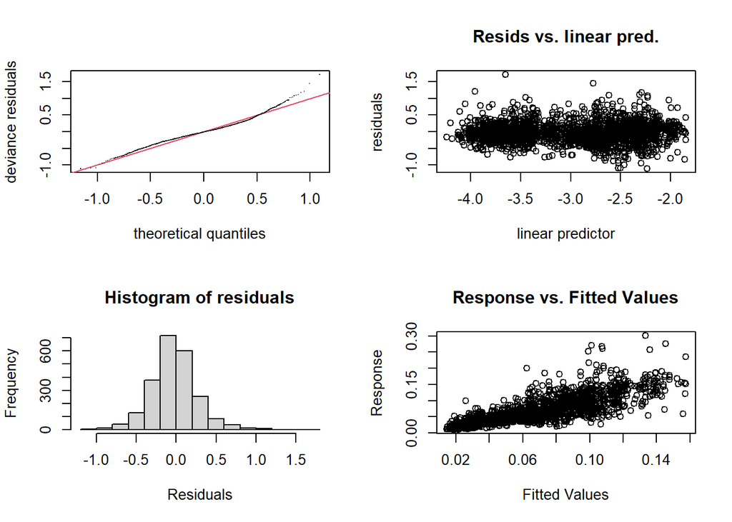

```
##
## Method: fREML   Optimizer: perf chol
## $grad
## [1] -8.478231e-07 -1.971248e-07  8.285077e-07 -3.544368e-06  3.169605e-07
## [6] -4.368545e-06  1.424903e-07  1.050229e-05
##
## $hess
##          [,1]         [,2]         [,3]          [,4]         [,5]         [,6]
##    2.15188521 -0.331463407   0.07647595   0.071571119   0.07731735   0.04572733
##   -0.33146341  3.054557807  -0.02197022  -0.008746429   0.02563698   0.13808799
##    0.07647595 -0.021970216   6.53889439   0.133106848   0.81098280   0.13453997
##    0.07157112 -0.008746429   0.13310685   4.040370365   0.19789010  -1.46749721
##    0.07731735  0.025636975   0.81098280   0.197890096  17.78379067  -0.03483138
##    0.04572733  0.138087986   0.13453997  -1.467497207  -0.03483138   8.62315310
##    0.04226569  0.136920237  -0.07275236  -0.012753762  -1.30364930  -0.24284288
## d -2.48970502 -3.093875802 -12.94961870 -15.963653077 -20.11602198 -24.77337389
##           [,7]        [,8]
##     0.04226569   -2.489705
##     0.13692024   -3.093876
##    -0.07275236  -12.949619
##    -0.01275376  -15.963653
##    -1.30364930  -20.116022
##    -0.24284288  -24.773374
##    19.74638464  -21.414953
## d -21.41495290 1134.499989
##
## Model rank =  963 / 963
##
## Basis dimension (k) checking results. Low p-value (k-index<1) may
## indicate that k is too low, especially if edf is close to k'.
##
##                                      k'    edf k-index p-value
## s(IPI)                             9.00   5.98    1.09       1
## s(IPI):whichC.ordprevocalic        9.00   7.19    1.09       1
## s(c2type,subj)                    94.00  25.90      NA      NA
## s(IPI,subj)                      423.00  72.16    1.09       1
## s(IPI,subj):whichC.ordprevocalic 423.00  92.38    1.09       1
```

```r
gam.check(mFinal.ord)
```

Fine.

Model criticism, trimming:

```r
df.nospr3 <- df.nospr[abs(scale(resid(mFinal.ord))) < 2.5, ] # trim model
(1 - (nrow(df.nospr3))/nrow(df.nospr)) * 100
```

```
## [1] 2.680141
```

2.7% gets removed.

Refit:

```r
summary(Final.ord_trim <- bam(durationC ~ group*c2type + whichC.ord + s(IPI) + s(IPI, by = whichC.ord)  + s(subj, c2type, bs = "re") + s(IPI, subj, bs = "fs", m =1) + s(IPI, subj, by = whichC.ord, bs = "fs", m =1), data = df.nospr3, family =Gamma(link=log), discrete = T, nthreads = 2))
```

```
##
## Family: Gamma
## Link function: log
##
## Formula:
## durationC ~ group * c2type + whichC.ord + s(IPI) + s(IPI, by = whichC.ord) +
##     s(subj, c2type, bs = "re") + s(IPI, subj, bs = "fs", m = 1) +
##     s(IPI, subj, by = whichC.ord, bs = "fs", m = 1)
##
## Parametric coefficients:
##                               Estimate Std. Error t value Pr(>|t|)
## (Intercept)                   -2.57576    0.07225 -35.653   <2e-16 ***
## grouptypical                   0.06492    0.10083   0.644   0.5198
## c2typelingual C2               0.04148    0.04564   0.909   0.3636
## whichC.ordprevocalic          -1.04090    0.06114 -17.024   <2e-16 ***
## grouptypical:c2typelingual C2 -0.17929    0.06272  -2.859   0.0043 **
## ---
## Signif. codes:  0 '***' 0.001 '**' 0.01 '*' 0.05 '.' 0.1 ' ' 1
##
## Approximate significance of smooth terms:
##                                      edf  Ref.df      F p-value
## s(IPI)                             6.534   7.351 11.804  <2e-16 ***
## s(IPI):whichC.ordprevocalic        7.434   8.007 28.411  <2e-16 ***
## s(c2type,subj)                    31.936  87.000  1.325  <2e-16 ***
## s(IPI,subj)                       95.209 414.000  6.052  <2e-16 ***
## s(IPI,subj):whichC.ordprevocalic 127.848 415.000  3.639  <2e-16 ***
## ---
## Signif. codes:  0 '***' 0.001 '**' 0.01 '*' 0.05 '.' 0.1 ' ' 1
##
## R-sq.(adj) =  0.795   Deviance explained = 87.9%
## fREML = 454.32  Scale est. = 0.064882  n = 2215
```

same pattern

Visualize:

```
## Summary:
##  * group : factor; set to the value(s): PD.
##  * c2type : factor; set to the value(s): labial C2, lingual C2. (Might be canceled as random effect, check below.)
##  * whichC.ord : factor; set to the value(s): prevocalic.
##  * IPI : numeric predictor; set to the value(s): 0.0488798370672098.
##  * subj : factor; set to the value(s): CTRL08. (Might be canceled as random effect, check below.)
##  * NOTE : The following random effects columns are canceled: s(c2type,subj),s(IPI,subj),s(IPI,subj):whichC.ordprevocalic
##
```

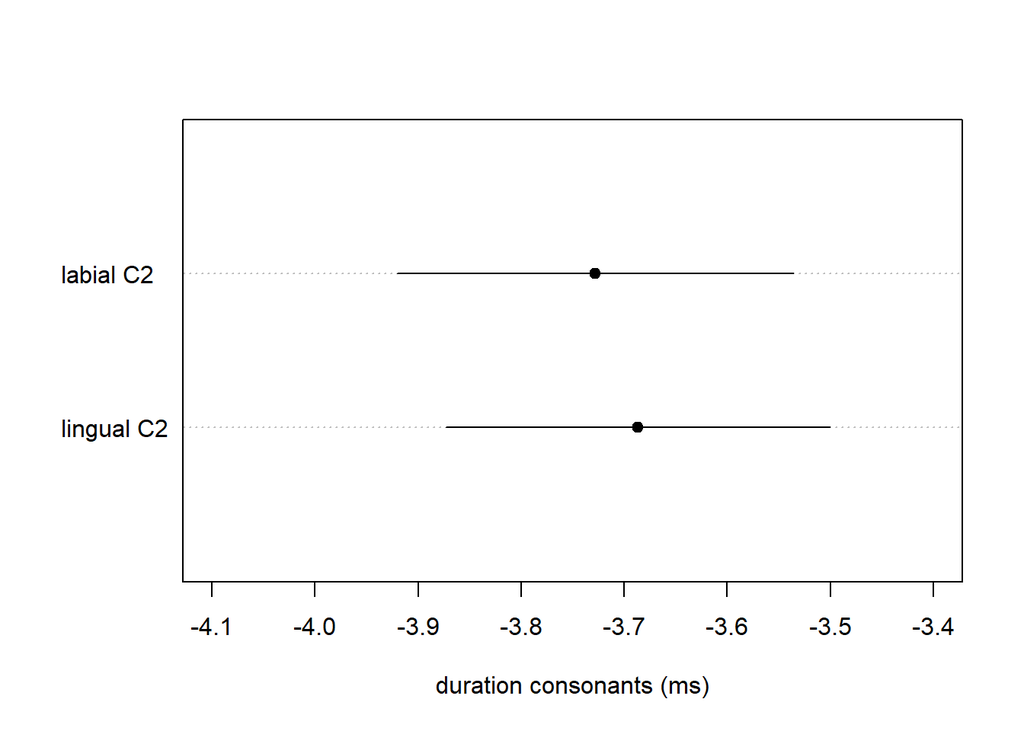

```r
plot_parametric(Final.ord_trim, cond = list(group = "PD"), pred=list(c2type = c("labial C2", "lingual C2")), main = "", xlab = "duration consonants (ms)", xlim=c(-4.1,-3.4))
```

```
## Summary:
##  * group : factor; set to the value(s): typical.
##  * c2type : factor; set to the value(s): labial C2, lingual C2. (Might be canceled as random effect, check below.)
##  * whichC.ord : factor; set to the value(s): prevocalic.
##  * IPI : numeric predictor; set to the value(s): 0.0488798370672098.
##  * subj : factor; set to the value(s): CTRL08. (Might be canceled as random effect, check below.)
##  * NOTE : The following random effects columns are canceled: s(c2type,subj),s(IPI,subj),s(IPI,subj):whichC.ordprevocalic
##
```

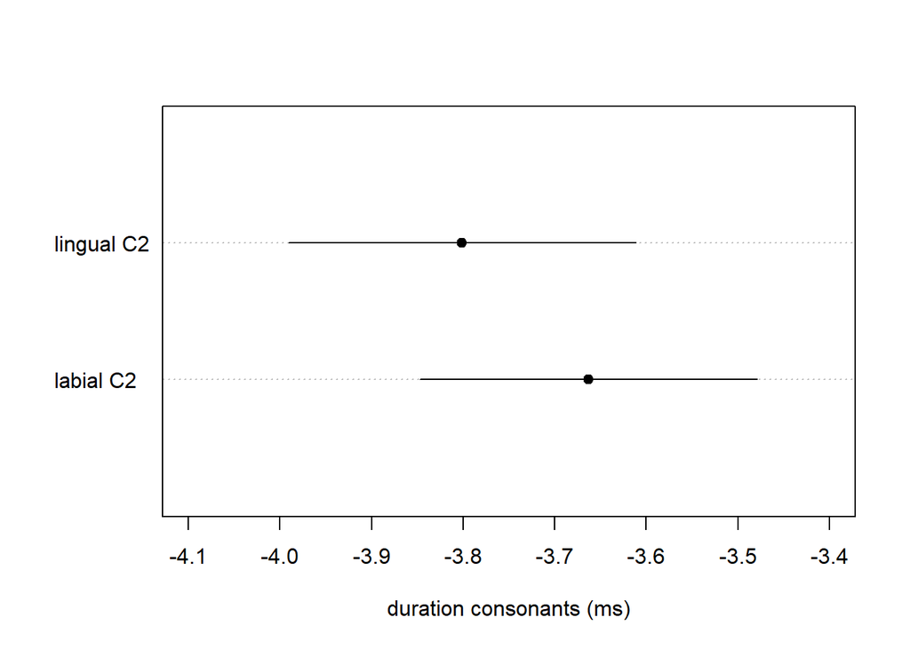

```r
plot_parametric(Final.ord_trim, cond = list(group = "typical"), pred=list(c2type = c("labial C2", "lingual C2")), main = "", xlab = "duration consonants (ms)", xlim=c(-4.1,-3.4))
```

```
## Summary:
##  * group : factor; set to the value(s): typical.
##  * c2type : factor; set to the value(s): labial C2. (Might be canceled as random effect, check below.)
##  * whichC.ord : factor; set to the value(s): initial, prevocalic.
##  * IPI : numeric predictor; with 30 values ranging from -0.117647 to 0.336918.
##  * subj : factor; set to the value(s): CTRL08. (Might be canceled as random effect, check below.)
##  * NOTE : The following random effects columns are canceled: s(c2type,subj),s(IPI,subj),s(IPI,subj):whichC.ordprevocalic
##
```

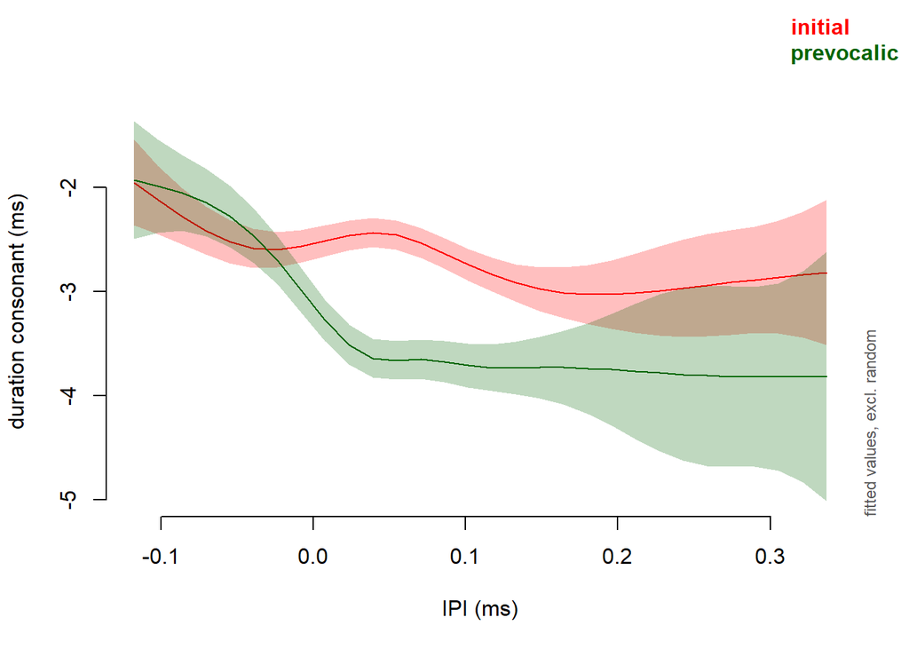

```r
plot_smooth(Final.ord_trim, view="IPI", plot_all="whichC.ord", rm.ranef=TRUE, xlab = "IPI (ms)", col=c("red", "darkgreen"), ylab = "duration consonant (ms)", rug=F)
```

Latex table function:

```r
gamtabs2 <- function (model, caption = " ", label = "tab.gam",
    pnames = NA, snames = NA, ptab = NA, stab = NA, ...)
{
    if (!requireNamespace("xtable", quietly = TRUE)) {
        stop("Package 'xtable' needed for this function to work. Please install it.",
            call. = FALSE)
    }
    sum.gam <- model
    if (!inherits(model, "summary.gam")) {
        sum.gam <- summary(model)
    }
    if (is.na(ptab[1])) {
        ptab = as.data.frame(sum.gam$p.table, stringsAsFactors = FALSE)
    }
    if (is.na(stab[1])) {
        stab = as.data.frame(sum.gam$s.table, stringsAsFactors = FALSE)
    }
    if (!is.na(pnames[1])) {
        rownames(ptab) = pnames
    }
    if (!is.na(snames[1])) {
        rownames(stab) = snames
    }
    colnames(ptab)[4] = "p-value"
    colnames(ptab)[3] = "t-value"
    ptab.cnames = colnames(ptab)
    stab.cnames = colnames(stab)
    stab.cnames[3] = "F-value"
    colnames(ptab) = c("A", "B", "C", "D")
    if (ncol(stab) != 0) {
        colnames(stab) = colnames(ptab)
    }
    tab = rbind(ptab, stab)
    colnames(tab) = ptab.cnames
    tab = round(tab, 4)
    m = data.frame(matrix(0, nrow(tab), ncol(tab)), stringsAsFactors = FALSE)
    for (i in 1:nrow(tab)) {
        for (j in 1:4) {
            if ((j == 4) & (tab[i, j] < 1e-03)) {
                m[i, j] = "< 0.001"
            }
            else {
                m[i, j] = sprintf("%3.3f", tab[i, j])
            }
        }
    }
    colnames(m) = colnames(tab)
    rownames(m) = rownames(tab)
    tab = m
    tab2 = rbind(c(ptab.cnames), tab[1:nrow(ptab), ])
    if (nrow(stab) > 0) {
        tab2 = rbind(tab2, c(stab.cnames), tab[(nrow(ptab) +
            1):nrow(tab), ])
    }
    if (nrow(stab)) {
        rownames(tab2)[(nrow(ptab) + 2)] = "B. smooth terms"
    }
    rownames(tab2)[1] = "A. parametric coefficients"
    for (i in 1:nrow(tab2)) {
        if (tab2[i, 4] == "0")
            tab2[i, 4] = "< 0.0001"
        if (length(grep("\\.", tab2[i, 2])) == 0)
            tab2[i, 2] = paste(tab2[i, 2], ".0000", sep = "")
    }
    print(xtable::xtable(tab2, caption = caption, label = label,
        align = "lrrrr"), include.colnames = FALSE, hline.after = c(0,
        (nrow(ptab) + 1), nrow(tab2)), ...)
}
```

Latex table:

```r
options(xtable.comment = FALSE)
gamtabs2(Final.ord_trim)
```

```
## \begin{table}[ht]
## \centering
## \begin{tabular}{lrrrr}
##    \hline
## A. parametric coefficients & Estimate & Std. Error & t-value & p-value \\
##   (Intercept) & -2.576 & 0.072 & -35.653 & $<$ 0.001 \\
##   grouptypical & 0.065 & 0.101 & 0.644 & 0.520 \\
##   c2typelingual C2 & 0.042 & 0.046 & 0.909 & 0.364 \\
##   whichC.ordprevocalic & -1.041 & 0.061 & -17.024 & $<$ 0.001 \\
##   grouptypical:c2typelingual C2 & -0.179 & 0.063 & -2.859 & 0.004 \\
##    \hline
## B. smooth terms & edf & Ref.df & F-value & p-value \\
##   s(IPI) & 6.534 & 7.351 & 11.804 & $<$ 0.001 \\
##   s(IPI):whichC.ordprevocalic & 7.434 & 8.007 & 28.411 & $<$ 0.001 \\
##   s(c2type,subj) & 31.936 & 87.000 & 1.325 & $<$ 0.001 \\
##   s(IPI,subj) & 95.209 & 414.000 & 6.052 & $<$ 0.001 \\
##   s(IPI,subj):whichC.ordprevocalic & 127.848 & 415.000 & 3.639 & $<$ 0.001 \\
##    \hline
## \end{tabular}
## \caption{ }
## \label{tab.gam}
## \end{table}
```